# NYPD Shooting

2023-02-01

### Load Libraries

First I will load the any necessary libraries

```r
library(tidyverse)
library(lubridate)
```

### Importing and Reading Data

Next, I will be importing the data through the URL and then reading the CSV file from it. This dataset is of New York Police Department shooting incidents and contains all the reported information such as location of incident, as well as details of victim and perpetrator.

For this assignment, I will try to explore this dataset and figure out if I identify patterns or factors that contribute to police-involved shootings in New York City based on this data. What insights can I gain from analyzing these patterns?

```r
url_in <- "https://data.cityofnewyork.us/api/views/833y-fsy8/rows.csv?accessType=DOWNLOAD"
nypd_shooting <- read_csv(url_in[1])
```

### View Dataset

```r
nypd_shooting
```

```
## # A tibble: 25,596 × 19
##    INCID…¹ OCCUR…² OCCUR…³ BORO  PRECI…⁴ JURIS…⁵ LOCAT…⁶ STATI…⁷ PERP_…⁸ PERP_…⁹
##      <dbl> <chr>   <time>  <chr>   <dbl>   <dbl> <chr>   <lgl>   <chr>   <chr>
##  1  2.36e8 11/11/… 15:04   BROO…      79       0 <NA>    FALSE   <NA>    <NA>
##  2  2.31e8 07/16/… 22:05   BROO…      72       0 <NA>    FALSE   45-64   M
##  3  2.31e8 07/11/… 01:09   BROO…      79       0 <NA>    FALSE   <18     M
##  4  2.38e8 12/11/… 13:42   BROO…      81       0 <NA>    FALSE   <NA>    <NA>
##  5  2.24e8 02/16/… 20:00   QUEE…     113       0 <NA>    FALSE   <NA>    <NA>
##  6  2.28e8 05/15/… 04:13   QUEE…     113       0 <NA>    TRUE    <NA>    <NA>
##  7  2.27e8 04/14/… 21:08   BRONX      42       0 COMMER… TRUE    <NA>    <NA>
##  8  2.38e8 12/10/… 19:30   BRONX      52       0 <NA>    FALSE   <NA>    <NA>
##  9  2.25e8 02/22/… 00:18   MANH…      34       0 <NA>    FALSE   <NA>    <NA>
## 10  2.25e8 03/07/… 06:15   BROO…      75       0 <NA>    TRUE    25-44   M
## # … with 25,586 more rows, 9 more variables: PERP_RACE <chr>,
## #   VIC_AGE_GROUP <chr>, VIC_SEX <chr>, VIC_RACE <chr>, X_COORD_CD <dbl>,
## #   Y_COORD_CD <dbl>, Latitude <dbl>, Longitude <dbl>, Lon_Lat <chr>, and
## #   abbreviated variable names ¹INCIDENT_KEY, ²OCCUR_DATE, ³OCCUR_TIME,
## #   ⁴PRECINCT, ⁵JURISDICTION_CODE, ⁶LOCATION_DESC, ⁷STATISTICAL_MURDER_FLAG,
## #   ⁸PERP_AGE_GROUP, ⁹PERP_SEX
```

### Summary

```r
summary(nypd_shooting)
```

```
##   INCIDENT_KEY        OCCUR_DATE         OCCUR_TIME           BORO
##  Min.   :  9953245   Length:25596       Length:25596      Length:25596
##  1st Qu.: 61593633   Class :character   Class1:hms        Class :character
##  Median : 86437258   Mode  :character   Class2:difftime   Mode  :character
##  Mean   :112382648                      Mode  :numeric
##  3rd Qu.:166660833
##  Max.   :238490103
##
##     PRECINCT      JURISDICTION_CODE LOCATION_DESC      STATISTICAL_MURDER_FLAG
##  Min.   :  1.00   Min.   :0.0000    Length:25596       Mode :logical
##  1st Qu.: 44.00   1st Qu.:0.0000    Class :character   FALSE:20668
##  Median : 69.00   Median :0.0000    Mode  :character   TRUE :4928
##  Mean   : 65.87   Mean   :0.3316
##  3rd Qu.: 81.00   3rd Qu.:0.0000
##  Max.   :123.00   Max.   :2.0000
##                   NA's   :2
##  PERP_AGE_GROUP       PERP_SEX          PERP_RACE         VIC_AGE_GROUP
##  Length:25596       Length:25596       Length:25596       Length:25596
##  Class :character   Class :character   Class :character   Class :character
##  Mode  :character   Mode  :character   Mode  :character   Mode  :character
##
##
##
##
##    VIC_SEX            VIC_RACE           X_COORD_CD        Y_COORD_CD
##  Length:25596       Length:25596       Min.   : 914928   Min.   :125757
##  Class :character   Class :character   1st Qu.:1000011   1st Qu.:182782
##  Mode  :character   Mode  :character   Median :1007715   Median :194038
##                                        Mean   :1009455   Mean   :207894
##                                        3rd Qu.:1016838   3rd Qu.:239429
##                                        Max.   :1066815   Max.   :271128
##
##     Latitude       Longitude        Lon_Lat
##  Min.   :40.51   Min.   :-74.25   Length:25596
##  1st Qu.:40.67   1st Qu.:-73.94   Class :character
##  Median :40.70   Median :-73.92   Mode  :character
##  Mean   :40.74   Mean   :-73.91
##  3rd Qu.:40.82   3rd Qu.:-73.88
##  Max.   :40.91   Max.   :-73.70
##
```

### Cleaning Data

Upon viewing the columns, it seems that many columns are not needed which include: PRECINCT, JURISDICTION_CODE, LOCATION_DESC, X_COORD_CD, Y_COORD_CD, and Lon_Lat - PRECINCT & JURISDICTION_CODE would not add much since we already have BORO and exact latitude & longitude - LOCATION_DESC has many missing values and we also have columns which describe location (lat, long) - X_COORD_CD & Y_COORD_CD are not needed since we have lat & long - Lon_Lat is redundant because we have lat & long separately

```r
nypd_shooting_2 <- nypd_shooting %>%
  select(-c(PRECINCT, JURISDICTION_CODE, LOCATION_DESC, X_COORD_CD, Y_COORD_CD, Lon_Lat))

nypd_shooting_2
```

```
## # A tibble: 25,596 × 13
##    INCID…¹ OCCUR…² OCCUR…³ BORO  STATI…⁴ PERP_…⁵ PERP_…⁶ PERP_…⁷ VIC_A…⁸ VIC_SEX
##      <dbl> <chr>   <time>  <chr> <lgl>   <chr>   <chr>   <chr>   <chr>   <chr>
##  1  2.36e8 11/11/… 15:04   BROO… FALSE   <NA>    <NA>    <NA>    18-24   M
##  2  2.31e8 07/16/… 22:05   BROO… FALSE   45-64   M       ASIAN … 25-44   M
##  3  2.31e8 07/11/… 01:09   BROO… FALSE   <18     M       BLACK   25-44   M
##  4  2.38e8 12/11/… 13:42   BROO… FALSE   <NA>    <NA>    <NA>    25-44   M
##  5  2.24e8 02/16/… 20:00   QUEE… FALSE   <NA>    <NA>    <NA>    25-44   M
##  6  2.28e8 05/15/… 04:13   QUEE… TRUE    <NA>    <NA>    <NA>    25-44   M
##  7  2.27e8 04/14/… 21:08   BRONX TRUE    <NA>    <NA>    <NA>    18-24   M
##  8  2.38e8 12/10/… 19:30   BRONX FALSE   <NA>    <NA>    <NA>    25-44   M
##  9  2.25e8 02/22/… 00:18   MANH… FALSE   <NA>    <NA>    <NA>    25-44   M
## 10  2.25e8 03/07/… 06:15   BROO… TRUE    25-44   M       BLACK … 25-44   M
## # … with 25,586 more rows, 3 more variables: VIC_RACE <chr>, Latitude <dbl>,
## #   Longitude <dbl>, and abbreviated variable names ¹INCIDENT_KEY, ²OCCUR_DATE,
## #   ³OCCUR_TIME, ⁴STATISTICAL_MURDER_FLAG, ⁵PERP_AGE_GROUP, ⁶PERP_SEX,
## #   ⁷PERP_RACE, ⁸VIC_AGE_GROUP
```

View NA’s

```r
apply(nypd_shooting_2, 2, function(x) any(is.na(x)))
```

```
##            INCIDENT_KEY              OCCUR_DATE              OCCUR_TIME
##                   FALSE                   FALSE                   FALSE
##                    BORO STATISTICAL_MURDER_FLAG          PERP_AGE_GROUP
##                   FALSE                   FALSE                    TRUE
##                PERP_SEX               PERP_RACE           VIC_AGE_GROUP
##                    TRUE                    TRUE                   FALSE
##                 VIC_SEX                VIC_RACE                Latitude
##                   FALSE                   FALSE                   FALSE
##               Longitude
##                   FALSE
```

After eliminating columns, it can be seen that many columns still have missing values and it’s important to handle it carefully.

Columns with missing values (N/A’s) include: PERP_AGE_GROUP, PERP_SEX, PERP_RACE

I think for missing values, I will not replace them with a value that exists in the field. I will likely replace an “N/A” with an unknown value. If for example, “PERP_AGE_GROUP” is N/A, I will likely replace that N/A with “unknown_age_group” and use that for analysis.

### Step 2: Tidy & Transform Data

Replace NA’s:

```r
nypd_shooting_2 <- nypd_shooting_2 %>%
  replace_na(list(PERP_AGE_GROUP = "UNKNOWN", PERP_SEX = "UNKNOWN", PERP_RACE = "UNKNOWN"))

nypd_shooting_2
```

```
## # A tibble: 25,596 × 13
##    INCID…¹ OCCUR…² OCCUR…³ BORO  STATI…⁴ PERP_…⁵ PERP_…⁶ PERP_…⁷ VIC_A…⁸ VIC_SEX
##      <dbl> <chr>   <time>  <chr> <lgl>   <chr>   <chr>   <chr>   <chr>   <chr>
##  1  2.36e8 11/11/… 15:04   BROO… FALSE   UNKNOWN UNKNOWN UNKNOWN 18-24   M
##  2  2.31e8 07/16/… 22:05   BROO… FALSE   45-64   M       ASIAN … 25-44   M
##  3  2.31e8 07/11/… 01:09   BROO… FALSE   <18     M       BLACK   25-44   M
##  4  2.38e8 12/11/… 13:42   BROO… FALSE   UNKNOWN UNKNOWN UNKNOWN 25-44   M
##  5  2.24e8 02/16/… 20:00   QUEE… FALSE   UNKNOWN UNKNOWN UNKNOWN 25-44   M
##  6  2.28e8 05/15/… 04:13   QUEE… TRUE    UNKNOWN UNKNOWN UNKNOWN 25-44   M
##  7  2.27e8 04/14/… 21:08   BRONX TRUE    UNKNOWN UNKNOWN UNKNOWN 18-24   M
##  8  2.38e8 12/10/… 19:30   BRONX FALSE   UNKNOWN UNKNOWN UNKNOWN 25-44   M
##  9  2.25e8 02/22/… 00:18   MANH… FALSE   UNKNOWN UNKNOWN UNKNOWN 25-44   M
## 10  2.25e8 03/07/… 06:15   BROO… TRUE    25-44   M       BLACK … 25-44   M
## # … with 25,586 more rows, 3 more variables: VIC_RACE <chr>, Latitude <dbl>,
## #   Longitude <dbl>, and abbreviated variable names ¹INCIDENT_KEY, ²OCCUR_DATE,
## #   ³OCCUR_TIME, ⁴STATISTICAL_MURDER_FLAG, ⁵PERP_AGE_GROUP, ⁶PERP_SEX,
## #   ⁷PERP_RACE, ⁸VIC_AGE_GROUP
```

```r
summary(nypd_shooting_2)
```

```
##   INCIDENT_KEY        OCCUR_DATE         OCCUR_TIME           BORO
##  Min.   :  9953245   Length:25596       Length:25596      Length:25596
##  1st Qu.: 61593633   Class :character   Class1:hms        Class :character
##  Median : 86437258   Mode  :character   Class2:difftime   Mode  :character
##  Mean   :112382648                      Mode  :numeric
##  3rd Qu.:166660833
##  Max.   :238490103
##  STATISTICAL_MURDER_FLAG PERP_AGE_GROUP       PERP_SEX
##  Mode :logical           Length:25596       Length:25596
##  FALSE:20668             Class :character   Class :character
##  TRUE :4928              Mode  :character   Mode  :character
##
##
##
##   PERP_RACE         VIC_AGE_GROUP        VIC_SEX            VIC_RACE
##  Length:25596       Length:25596       Length:25596       Length:25596
##  Class :character   Class :character   Class :character   Class :character
##  Mode  :character   Mode  :character   Mode  :character   Mode  :character
##
##
##
##     Latitude       Longitude
##  Min.   :40.51   Min.   :-74.25
##  1st Qu.:40.67   1st Qu.:-73.94
##  Median :40.70   Median :-73.92
##  Mean   :40.74   Mean   :-73.91
##  3rd Qu.:40.82   3rd Qu.:-73.88
##  Max.   :40.91   Max.   :-73.70
```

Now it can be seen that no column has missing values.

Next I want to find unique values to see if there are any outliers. #### Find Unique values:

```r
unique(nypd_shooting_2$BORO)
```

```
## [1] "BROOKLYN"      "QUEENS"        "BRONX"         "MANHATTAN"
## [5] "STATEN ISLAND"
```

```r
unique(nypd_shooting_2$STATISTICAL_MURDER_FLAG)
```

```
## [1] FALSE  TRUE
```

```r
unique(nypd_shooting_2$PERP_AGE_GROUP)
```

```
## [1] "UNKNOWN" "45-64"   "<18"     "25-44"   "18-24"   "65+"     "1020"
## [8] "940"     "224"
```

```r
unique(nypd_shooting_2$PERP_SEX)
```

```
## [1] "UNKNOWN" "M"       "F"       "U"
```

```r
unique(nypd_shooting_2$PERP_RACE)
```

```
## [1] "UNKNOWN"                        "ASIAN / PACIFIC ISLANDER"
## [3] "BLACK"                          "BLACK HISPANIC"
## [5] "WHITE HISPANIC"                 "WHITE"
## [7] "AMERICAN INDIAN/ALASKAN NATIVE"
```

```r
unique(nypd_shooting_2$VIC_AGE_GROUP)
```

```
## [1] "18-24"   "25-44"   "<18"     "45-64"   "65+"     "UNKNOWN"
```

```r
unique(nypd_shooting_2$VIC_SEX)
```

```
## [1] "M" "F" "U"
```

```r
unique(nypd_shooting_2$VIC_RACE)
```

```
## [1] "BLACK"                          "ASIAN / PACIFIC ISLANDER"
## [3] "BLACK HISPANIC"                 "WHITE HISPANIC"
## [5] "WHITE"                          "AMERICAN INDIAN/ALASKAN NATIVE"
## [7] "UNKNOWN"
```

Based on the unique() function, PERP_AGE_GROUP has some odd values which should be excluded:

```r
nypd_shooting_2 <- filter(nypd_shooting_2,
                          PERP_AGE_GROUP != "1020" & PERP_AGE_GROUP != "940" & PERP_AGE_GROUP != "224")
unique(nypd_shooting_2$PERP_AGE_GROUP)
```

```
## [1] "UNKNOWN" "45-64"   "<18"     "25-44"   "18-24"   "65+"
```

Make sure that all unknowns are the same

```r
nypd_shooting_2$PERP_SEX[nypd_shooting_2$PERP_SEX == "U"] <- "UNKNOWN"
summary(nypd_shooting_2)
```

```
##   INCIDENT_KEY        OCCUR_DATE         OCCUR_TIME           BORO
##  Min.   :  9953245   Length:25593       Length:25593      Length:25593
##  1st Qu.: 61593632   Class :character   Class1:hms        Class :character
##  Median : 86437258   Mode  :character   Class2:difftime   Mode  :character
##  Mean   :112383964                      Mode  :numeric
##  3rd Qu.:166660833
##  Max.   :238490103
##  STATISTICAL_MURDER_FLAG PERP_AGE_GROUP       PERP_SEX
##  Mode :logical           Length:25593       Length:25593
##  FALSE:20665             Class :character   Class :character
##  TRUE :4928              Mode  :character   Mode  :character
##
##
##
##   PERP_RACE         VIC_AGE_GROUP        VIC_SEX            VIC_RACE
##  Length:25593       Length:25593       Length:25593       Length:25593
##  Class :character   Class :character   Class :character   Class :character
##  Mode  :character   Mode  :character   Mode  :character   Mode  :character
##
##
##
##     Latitude       Longitude
##  Min.   :40.51   Min.   :-74.25
##  1st Qu.:40.67   1st Qu.:-73.94
##  Median :40.70   Median :-73.92
##  Mean   :40.74   Mean   :-73.91
##  3rd Qu.:40.82   3rd Qu.:-73.88
##  Max.   :40.91   Max.   :-73.70
```

### Step 3: Add Visualizations and Analysis

First, I will create a bar chart to see the number of shooting incidents in each borough:

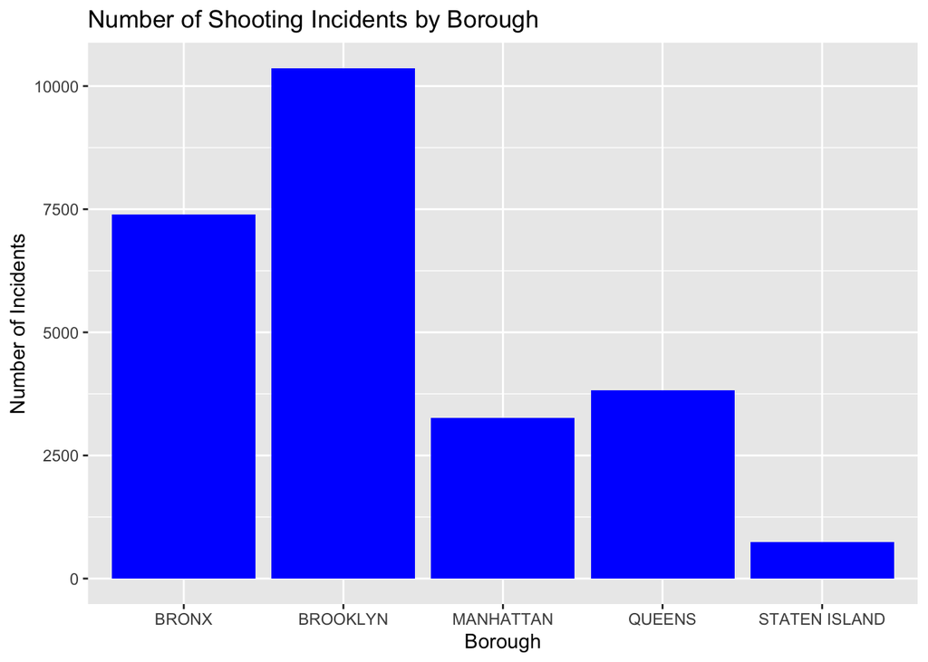

```r
nypd_shooting_2 %>%
  ggplot(aes(x = BORO)) +
  geom_bar(fill = "blue") +
  ggtitle("Number of Shooting Incidents by Borough") +
  xlab("Borough") +
  ylab("Number of Incidents")
```

Based on this plot, it can be seen that Brooklyn has the most number of shooting incidents followed by Bronx. Staten Island has the least number of incidents.

#### Next, I will create a histogram with the number of shootings per victim’s age group.

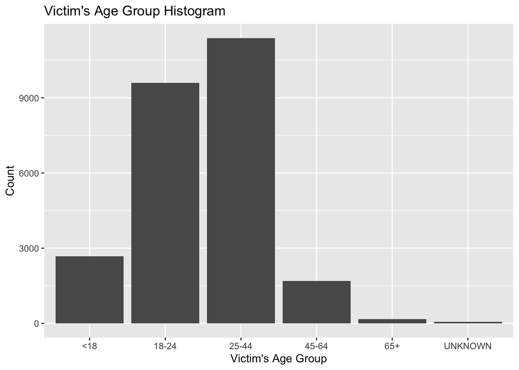

```r
ggplot(nypd_shooting_2, aes(x = VIC_AGE_GROUP)) +
  geom_bar(binwidth = 1) +
  xlab("Victim's Age Group") +
  ylab("Count") +
  ggtitle("Victim's Age Group Histogram")
```

#### Modeling:

For this analysis, I will be using logistic regression to to predict the STATISTICAL_MURDER_FLAG using BORO, PERP_AGE_GROUP, PERP_SEX, PERP_RACE, Latitude, and Longitude as predictors:

```r
nypd_shooting_2$PERP_AGE_GROUP = as.factor(nypd_shooting_2$PERP_AGE_GROUP)
nypd_shooting_2$PERP_SEX = as.factor(nypd_shooting_2$PERP_SEX)
nypd_shooting_2$PERP_RACE = as.factor(nypd_shooting_2$PERP_RACE)
# Fit a logistic regression model
model <- glm(STATISTICAL_MURDER_FLAG ~ BORO + PERP_AGE_GROUP + PERP_SEX + PERP_RACE + Latitude + Longitude, data = nypd_shooting_2, family = binomial())

# Print the model summary
summary(model)
```

```
##
## Call:
## glm(formula = STATISTICAL_MURDER_FLAG ~ BORO + PERP_AGE_GROUP +
##     PERP_SEX + PERP_RACE + Latitude + Longitude, family = binomial(),
##     data = nypd_shooting_2)
##
## Deviance Residuals:
##     Min       1Q   Median       3Q      Max
## -1.9216  -0.6852  -0.6104  -0.2219   2.9545
##
## Coefficients:
##                                   Estimate Std. Error z value Pr(>|z|)
## (Intercept)                       29.58294   93.27601   0.317 0.751126
## BOROBROOKLYN                       0.15898    0.10040   1.584 0.113295
## BOROMANHATTAN                     -0.06042    0.06622  -0.912 0.361550
## BOROQUEENS                         0.02951    0.09881   0.299 0.765238
## BOROSTATEN ISLAND                  0.16750    0.18248   0.918 0.358675
## PERP_AGE_GROUP18-24                0.16915    0.07534   2.245 0.024753 *
## PERP_AGE_GROUP25-44                0.50638    0.07498   6.754 1.44e-11 ***
## PERP_AGE_GROUP45-64                0.83385    0.11458   7.278 3.40e-13 ***
## PERP_AGE_GROUP65+                  1.01333    0.28271   3.584 0.000338 ***
## PERP_AGE_GROUPUNKNOWN             -2.24151    0.17120 -13.093  < 2e-16 ***
## PERP_SEXM                         -0.19255    0.12101  -1.591 0.111570
## PERP_SEXUNKNOWN                    2.42772    0.26827   9.049  < 2e-16 ***
## PERP_RACEASIAN / PACIFIC ISLANDER  9.98168   84.38790   0.118 0.905843
## PERP_RACEBLACK                     9.50808   84.38770   0.113 0.910291
## PERP_RACEBLACK HISPANIC            9.39368   84.38773   0.111 0.911366
## PERP_RACEUNKNOWN                   9.03065   84.38795   0.107 0.914778
## PERP_RACEWHITE                    10.16647   84.38780   0.120 0.904108
## PERP_RACEWHITE HISPANIC            9.67097   84.38771   0.115 0.908761
## Latitude                           0.28807    0.50108   0.575 0.565369
## Longitude                          0.70671    0.46805   1.510 0.131066
## ---
## Signif. codes:  0 '***' 0.001 '**' 0.01 '*' 0.05 '.' 0.1 ' ' 1
##
## (Dispersion parameter for binomial family taken to be 1)
##
##     Null deviance: 25076  on 25592  degrees of freedom
## Residual deviance: 24152  on 25573  degrees of freedom
## AIC: 24192
##
## Number of Fisher Scoring iterations: 9
```

From the summary, we can see that Pr(>|z|) column represents the p-value associated with the value in the z value column. If the p-value is less than 0.05, it means that the predictor variable has a statistically significant relationship with the response variable. Some of these predictor variables having significant relationship with STATISTICAL_MURDER_FLAG are PERP_AGE_GROUP18-24, PERP_AGE_GROUP25-44, PERP_AGE_GROUP45-64, and PERP_AGE_GROUP65+.

### Step 4: Bias

Some possible sources of bias might include under-reporting. This means that perhaps not all incidents have been reported to he police. Furthermore, this data relies on reporters and those who have recorded such information. It is possible that there are errors in the reporting itself.

With regards to my personal bias, I think this dataset does confirm some of my beliefs. I view New York city as having a high crime rate and was not too surprised to see that Brooklyn and Bronx have the highest number of incidents. I was also not surprised to see Staten Island having lower incidents compared to Brooklyn and Bronx. Secondly, I am also not too surprised to see that the most number of victims are between the age 25 to 44. I am very surprised to see victim’s under the age of 18. It’s disheartening to see young people be victims of such incidents.